# Analyzing data on the level of cognitive processes - ESCoP 2025

Gidon T. Frischkorn, Ruhi Bhanap, and Isabel Courage

# Solutions: Exercise 5 - EZ-Diffusion Model (Visual Search Task)

In this exercise, we will have a look at estimating the parameters from the diffusion decision model using the hierarchical Bayesian implementation of the ez-Diffusion Model. This implementation allows for a fast parameter estimation while still providing acceptable recovery of three parameters of interest:

1. drift rate = the rate of evidence accumulation
2. boundary seperation = the seperation of decision thresholds
3. non-decision time = the time for non-decisional processes.

Your task is to load one of the data sets we prepared for this exercise, either `exercise5_VisualSearch.txt` or `exc5_ColorJudgement.txt`.

The Color Judgement data set contains data of 50 participants that completed a Color Judgement task. In this task participants saw an array of blue and red dots and should decide if the array contained more blue or red dots. There were two difficulty levels, the easy level in which 60% of the dots were either blue or red, and the difficult level in which 52% of the dots were either blue or red.

he Visual Search data set contains data for 33 participants that completed the Visual Search task. In this task, participants were presented a color cue, a positive (the target color), a negative (the non target color) or neutral (not part of the visual search display). Participants had to look for a “C” that either looked upwards or downwards and report it´s direction with the arrow key.

Your task is:

1. aggregate the data, so that we can estimate the `ezdm`
2. to specify the `ezdm` model object matching the aggreaged data of the task
3. specify a model formula predicting which parameters you assume to vary as a function of the difficulty level
4. estimate the model using the `bmm` function and interpret the results with respect to the experimental effects on the model parameters

## Solution

```r
# Load required packages
library(bmm)
library(tidyverse)
library(here)
```

### Prepare Data

First, we need to aggregate the data so that we can analyze our data with the `ezdm` using the `bmm` function. For this, we need to calcualte the mean reaction time, the variance of the reaction time, the number of correct responses, and the number of trials in each cell of the experimental design.

```r
ezdm_data <- read.table(here("data","exercise5_visualsearchtask.txt"),
                 header = TRUE, sep = " ")

ezdm_data_agg<- ezdm_data %>%
  summarise(
    mean_rt = mean(RT/1000),
    var_rt = var(RT/1000),
    n_correct = sum(acc),
    n_trials = n(),
    .by = c("participant", "condition", "correct")
  )

ezdm_data_agg$condition <- as.factor(ezdm_data_agg$condition)
contrasts(ezdm_data_agg$condition) <- bayestestR::contr.equalprior
```

### Specify Model object

Next, we need to specify the model object to link which data columns are used to identify the `ezdm`

```r
ezdm_model <- ezdm(mean_rt = "mean_rt", var_rt = "var_rt", n_correct = "n_correct",
                   n_trials = "n_trials")
```

### Specify the BMM formula

Now, we can consider which parameters are affected by the experimental manipulations. First, let’s see how the `ezdm` parameter vary as a function of the cue manipulation.

```r
ezdm_formula <- bmf(
  drift ~ 0 + condition + (0 + condition | participant),
  bound ~   1 + ( 1 | participant),
  ndt ~  0 + condition + (0 + condition | participant)
)
```

### Estimate `ezdm` with the `bmm` function

Finally, we can estimate the model using our aggregated data, the `bmmodel` object we created and the `bmmformula` specifying how the model parameters should change over experimental condition.

```r
ezdm_fit <- bmm(
  formula = ezdm_formula,
  data = ezdm_data_agg,
  model = ezdm_model,
  cores = 4,
  sample_prior = TRUE,
  refresh = 0,
  file = here("models","ezdm_visualsearch_exc5")
)
```

```
## Running MCMC with 4 parallel chains...
##
## Chain 4 finished in 10.3 seconds.
## Chain 1 finished in 10.5 seconds.
## Chain 2 finished in 11.8 seconds.
## Chain 3 finished in 13.1 seconds.
##
## All 4 chains finished successfully.
## Mean chain execution time: 11.4 seconds.
## Total execution time: 13.2 seconds.
```

```r
summary(ezdm_fit)
```

```
##   Model: ezdm(mean_rt = "mean_rt",
##               var_rt = "var_rt",
##               n_correct = "n_correct",
##               n_trials = "n_trials")
##   Links: drift = identity; bound = log; ndt = log
## Formula: drift ~ 0 + condition + (0 + condition | participant)
##          bound ~ 1 + (1 | participant)
##          ndt ~ 0 + condition + (0 + condition | participant)
##    Data: ezdm_data_agg (Number of observations: 198)
##   Draws: 4 chains, each with iter = 2000; warmup = 1000; thin = 1;
##          total post-warmup draws = 4000
##
## Multilevel Hyperparameters:
## ~participant (Number of levels: 33)
##                                                      Estimate Est.Error
## sd(drift_conditionnegative)                              0.12      0.03
## sd(drift_conditionneutral)                               0.04      0.03
## sd(drift_conditionpositive)                              0.19      0.03
## sd(bound_Intercept)                                      0.04      0.02
## sd(ndt_conditionnegative)                                0.21      0.04
## sd(ndt_conditionneutral)                                 0.18      0.04
## sd(ndt_conditionpositive)                                0.23      0.04
## cor(drift_conditionnegative,drift_conditionneutral)      0.13      0.45
## cor(drift_conditionnegative,drift_conditionpositive)     0.70      0.18
## cor(drift_conditionneutral,drift_conditionpositive)      0.14      0.43
## cor(ndt_conditionnegative,ndt_conditionneutral)          0.69      0.16
## cor(ndt_conditionnegative,ndt_conditionpositive)         0.76      0.13
## cor(ndt_conditionneutral,ndt_conditionpositive)          0.82      0.13
##                                                      l-95% CI u-95% CI Rhat
## sd(drift_conditionnegative)                              0.07     0.19 1.00
## sd(drift_conditionneutral)                               0.00     0.11 1.00
## sd(drift_conditionpositive)                              0.13     0.26 1.00
## sd(bound_Intercept)                                      0.00     0.08 1.00
## sd(ndt_conditionnegative)                                0.15     0.29 1.00
## sd(ndt_conditionneutral)                                 0.12     0.26 1.00
## sd(ndt_conditionpositive)                                0.16     0.32 1.00
## cor(drift_conditionnegative,drift_conditionneutral)     -0.79     0.89 1.00
## cor(drift_conditionnegative,drift_conditionpositive)     0.26     0.96 1.00
## cor(drift_conditionneutral,drift_conditionpositive)     -0.77     0.88 1.00
## cor(ndt_conditionnegative,ndt_conditionneutral)          0.32     0.94 1.00
```

[output cut: 23 more lines]

```
## ndt_conditionnegative      -0.30      0.05    -0.40    -0.21 1.00      898
## ndt_conditionneutral       -0.27      0.05    -0.36    -0.18 1.00     1141
## ndt_conditionpositive      -0.47      0.05    -0.58    -0.37 1.00     1028
##                         Tail_ESS
## bound_Intercept             2187
## drift_conditionnegative     2790
## drift_conditionneutral      2810
## drift_conditionpositive     3057
## ndt_conditionnegative       1672
## ndt_conditionneutral        1851
## ndt_conditionpositive       1737
##
## Draws were sampled using sample(hmc). For each parameter, Bulk_ESS
## and Tail_ESS are effective sample size measures, and Rhat is the potential
## scale reduction factor on split chains (at convergence, Rhat = 1).
```

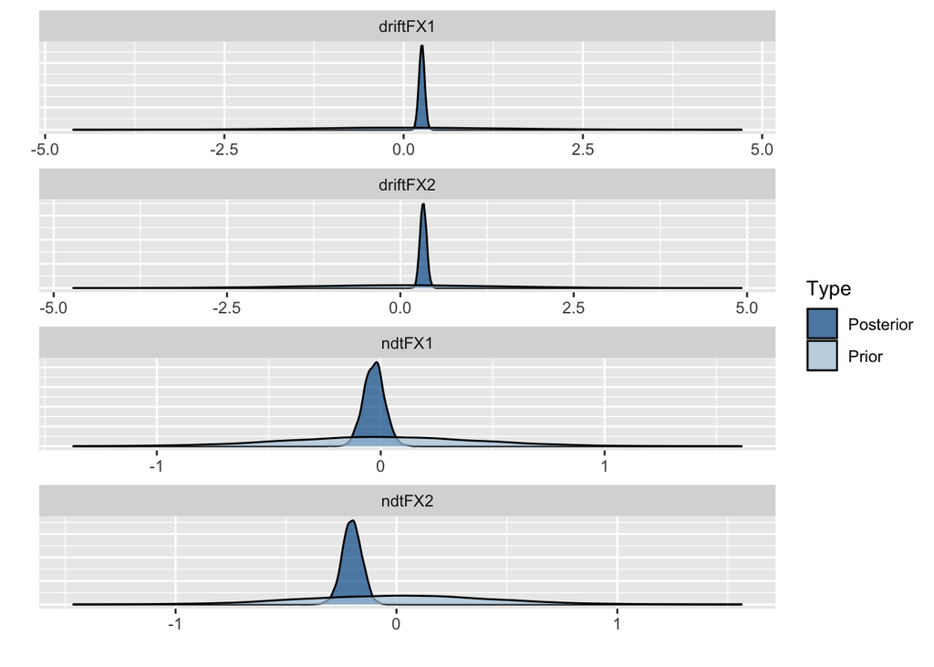

```r
ezdm_hypothesis <- c(
  driftFX1 = "drift_conditionnegative = drift_conditionneutral",
  driftFX2 = "drift_conditionpositive = drift_conditionneutral",
  ndtFX1 = "ndt_conditionnegative = ndt_conditionneutral",
  ndtFX2 = "ndt_conditionpositive = ndt_conditionneutral"
)

ezdm_hypothesis_results <- brms::hypothesis(
  ezdm_fit,
  ezdm_hypothesis
)

plot(ezdm_hypothesis_results)
```

```r
1/abs(ezdm_hypothesis_results$hypothesis$Evid.Ratio)
```

```
## [1] 2.149295e+15 1.099526e+18 1.308322e-01 5.954875e+02
```